# Создание модели персонализиции предложения постоянным клиентам

Интернет-магазин «В один клик» продаёт разные товары: для детей, для дома, мелкую бытовую технику, косметику и даже продукты. Отчёт магазина за прошлый период показал, что активность покупателей начала снижаться. Привлекать новых клиентов уже не так эффективно: о магазине и так знает большая часть целевой аудитории. Возможный выход — удерживать активность постоянных клиентов. Сделать это можно с помощью персонализированных предложений.

«В один клик» — современная компания, поэтому её руководство не хочет принимать решения просто так — только на основе анализа данных и бизнес-моделирования. У компании есть небольшой отдел цифровых технологий, и вам предстоит побыть в роли стажёра в этом отделе.

Итак, вашему отделу поручили разработать решение, которое позволит персонализировать предложения постоянным клиентам, чтобы увеличить их покупательскую активность.

Описание данных:

- Таблица *df_market*:
  - `id` — номер покупателя в корпоративной базе данных.
  - `Покупательская активность` — рассчитанный класс покупательской активности (целевой признак): «снизилась» или «прежний уровень».
  - `Тип сервиса` — уровень сервиса, например «премиум» и «стандарт».
  - `Разрешить сообщать` — информация о том, можно ли присылать покупателю дополнительные предложения о товаре. Согласие на это даёт покупатель.
  - `Маркет_актив_6_мес` — среднемесячное значение маркетинговых коммуникаций компании, которое приходилось на покупателя за - последние 6 месяцев. Это значение показывает, какое число рассылок, звонков, показов рекламы и прочего приходилось на клиента.
  - `Маркет_актив_тек_мес` — количество маркетинговых коммуникаций в текущем месяце.
  - `Длительность` — значение, которое показывает, сколько дней прошло с момента регистрации покупателя на сайте.
  - `Акционные_покупки` — среднемесячная доля покупок по акции от общего числа покупок за последние 6 месяцев.
  - `Популярная_категория` — самая популярная категория товаров у покупателя за последние 6 месяцев.
  - `Средний_просмотр_категорий_за_визит` — показывает, сколько в среднем категорий покупатель просмотрел за визит в течение последнего месяца.
  - `Неоплаченные_продукты_штук_квартал` — общее число неоплаченных товаров в корзине за последние 3 месяца.
  - `Ошибка_сервиса` — число сбоев, которые коснулись покупателя во время посещения сайта.
  - `Страниц_за_визит` — среднее количество страниц, которые просмотрел покупатель за один визит на сайт за последние 3 месяца.
- Таблица *df_market_money*:
  - `id` — номер покупателя в корпоративной базе данных.
  - `Период` — название периода, во время которого зафиксирована выручка. Например, 'текущий_месяц' или 'предыдущий_месяц'.
  - `Выручка` — сумма выручки за период.
- Таблица *df_time*:
  - `id` — номер покупателя в корпоративной базе данных.
  - `Период` — название периода, во время которого зафиксировано общее время.
  - `минут` — значение времени, проведённого на сайте, в минутах.
- Таблица *df_money*:
  - `id` — номер покупателя в корпоративной базе данных.
  - `Прибыль` — значение прибыли.

Целью работы является разработка модели машинного обучения персонализации предложения постоянным клиентам для увеличения их покупательской активности.

Исследование разделим на этапы:

- Загрузка данных
- Предобработка данных
- Исследовательский анализ данных
- Объединение таблиц
- Корреляционный анализ
- Использование пайплайнов
- Анализ важности признаков
- Сегментация покупателей
- Выводы

```python
def autopct_format(values):
    def my_format(pct):
        total = sum(values)
        val = int(round(pct * total / 100.0))
        return f'{pct:.1f}%\n({val:d})'
    return my_format


def cat_col_graphics(df, column):

    fig, axes = plt.subplots(1, 2, figsize=(15, 6))

    sns.countplot(data=df, x=column, ax=axes[0], color='lightskyblue', edgecolor='black', alpha=0.6)
    axes[0].set_title(f'Диаграмма распределения признака {column}')
    axes[0].set_xlabel(f'Значения столбца {column}\n')
    axes[0].set_ylabel('Частота')

    df[column].value_counts().plot.pie(ax=axes[1], autopct=autopct_format(df[column].value_counts()),
                                       wedgeprops={'edgecolor': 'black', 'linewidth': 1})
    axes[1].set_title(f'Круговая диаграмма для признака {column}')
    axes[1].set_ylabel('')
```

```python
#!pip install scikit-learn==1.1.3 matplotlib==3.5.1 phik shap -q
```

```python
import pandas as pd
import matplotlib.pyplot as plt
%matplotlib inline
import seaborn as sns
import numpy as np
from sklearn.model_selection import train_test_split, RandomizedSearchCV, GridSearchCV
from sklearn.preprocessing import OneHotEncoder, OrdinalEncoder, StandardScaler, MinMaxScaler
from sklearn.linear_model import LinearRegression, LogisticRegression
from sklearn.metrics import (r2_score, mean_squared_error, mean_absolute_error,
    accuracy_score, precision_score, recall_score, f1_score, roc_auc_score, confusion_matrix)
from sklearn.pipeline import Pipeline
from sklearn.compose import ColumnTransformer
from sklearn.impute import SimpleImputer
from sklearn.neighbors import KNeighborsClassifier
from sklearn.tree import DecisionTreeClassifier
from sklearn.svm import SVC
from phik import phik_matrix
from phik.report import plot_correlation_matrix
import shap

RANDOM_STATE = 42
TEST_SIZE = 0.25
```

## Загрузка данных

```python
df_market = pd.read_csv('/datasets/market_file.csv')
df_market_money = pd.read_csv('/datasets/market_money.csv', sep=',')
df_time = pd.read_csv('/datasets/market_time.csv', sep=',')
df_money = pd.read_csv('/datasets/money.csv', sep=';', decimal=',')
```

```python
df_market.head()
```

|  | id | Покупательская активность | Тип сервиса | Разрешить сообщать | Маркет_актив_6_мес | Маркет_актив_тек_мес | Длительность | Акционные_покупки | Популярная_категория | Средний_просмотр_категорий_за_визит | Неоплаченные_продукты_штук_квартал | Ошибка_сервиса | Страниц_за_визит |
| --- | --- | --- | --- | --- | --- | --- | --- | --- | --- | --- | --- | --- | --- |
| 0 | 215348 | Снизилась | премиум | да | 3.4 | 5 | 121 | 0.00 | Товары для детей | 6 | 2 | 1 | 5 |
| 1 | 215349 | Снизилась | премиум | да | 4.4 | 4 | 819 | 0.75 | Товары для детей | 4 | 4 | 2 | 5 |
| 2 | 215350 | Снизилась | стандартт | нет | 4.9 | 3 | 539 | 0.14 | Домашний текстиль | 5 | 2 | 1 | 5 |
| 3 | 215351 | Снизилась | стандартт | да | 3.2 | 5 | 896 | 0.99 | Товары для детей | 5 | 0 | 6 | 4 |
| 4 | 215352 | Снизилась | стандартт | нет | 5.1 | 3 | 1064 | 0.94 | Товары для детей | 3 | 2 | 3 | 2 |

```python
df_market.info()
```

```
<class 'pandas.core.frame.DataFrame'>
RangeIndex: 1300 entries, 0 to 1299
Data columns (total 13 columns):
 #   Column                               Non-Null Count  Dtype
---  ------                               --------------  -----
 0   id                                   1300 non-null   int64
 1   Покупательская активность            1300 non-null   object
 2   Тип сервиса                          1300 non-null   object
 3   Разрешить сообщать                   1300 non-null   object
 4   Маркет_актив_6_мес                   1300 non-null   float64
 5   Маркет_актив_тек_мес                 1300 non-null   int64
 6   Длительность                         1300 non-null   int64
 7   Акционные_покупки                    1300 non-null   float64
 8   Популярная_категория                 1300 non-null   object
 9   Средний_просмотр_категорий_за_визит  1300 non-null   int64
 10  Неоплаченные_продукты_штук_квартал   1300 non-null   int64
 11  Ошибка_сервиса                       1300 non-null   int64
 12  Страниц_за_визит                     1300 non-null   int64
dtypes: float64(2), int64(7), object(4)
memory usage: 132.2+ KB
```

```python
df_market.describe()
```

|  | id | Маркет_актив_6_мес | Маркет_актив_тек_мес | Длительность | Акционные_покупки | Средний_просмотр_категорий_за_визит | Неоплаченные_продукты_штук_квартал | Ошибка_сервиса | Страниц_за_визит |
| --- | --- | --- | --- | --- | --- | --- | --- | --- | --- |
| count | 1300.000000 | 1300.000000 | 1300.000000 | 1300.000000 | 1300.000000 | 1300.00000 | 1300.000000 | 1300.000000 | 1300.000000 |
| mean | 215997.500000 | 4.253769 | 4.011538 | 601.898462 | 0.319808 | 3.27000 | 2.840000 | 4.185385 | 8.176923 |
| std | 375.421985 | 1.014814 | 0.696868 | 249.856289 | 0.249843 | 1.35535 | 1.971451 | 1.955298 | 3.978126 |
| min | 215348.000000 | 0.900000 | 3.000000 | 110.000000 | 0.000000 | 1.00000 | 0.000000 | 0.000000 | 1.000000 |
| 25% | 215672.750000 | 3.700000 | 4.000000 | 405.500000 | 0.170000 | 2.00000 | 1.000000 | 3.000000 | 5.000000 |
| 50% | 215997.500000 | 4.200000 | 4.000000 | 606.000000 | 0.240000 | 3.00000 | 3.000000 | 4.000000 | 8.000000 |
| 75% | 216322.250000 | 4.900000 | 4.000000 | 806.000000 | 0.300000 | 4.00000 | 4.000000 | 6.000000 | 11.000000 |
| max | 216647.000000 | 6.600000 | 5.000000 | 1079.000000 | 0.990000 | 6.00000 | 10.000000 | 9.000000 | 20.000000 |

```python
df_market.isna().sum()
```

```
id                                     0
Покупательская активность              0
Тип сервиса                            0
Разрешить сообщать                     0
Маркет_актив_6_мес                     0
Маркет_актив_тек_мес                   0
Длительность                           0
Акционные_покупки                      0
Популярная_категория                   0
Средний_просмотр_категорий_за_визит    0
Неоплаченные_продукты_штук_квартал     0
Ошибка_сервиса                         0
Страниц_за_визит                       0
dtype: int64
```

```python
df_market.shape
```

```
(1300, 13)
```

Таким образом, в датасете *df_market* 1300 сточки и 13 признаков. У столбцов `id`, `Маркет_актив_тек_мес`, `Длительность`, `Средний_просмотр_категорий_за_визит`, `Неоплаченные_продукты_штук_квартал`, `Ошибка_сервиса` и `Страниц_за_визит` тип данных int64, у столбцов `Маркет_актив_6_мес`, `Акционные_покупки` - float64, у остальных - object. Пропусков в данных нет.

```python
df_market_money.head()
```

|  | id | Период | Выручка |
| --- | --- | --- | --- |
| 0 | 215348 | препредыдущий_месяц | 0.0 |
| 1 | 215348 | текущий_месяц | 3293.1 |
| 2 | 215348 | предыдущий_месяц | 0.0 |
| 3 | 215349 | препредыдущий_месяц | 4472.0 |
| 4 | 215349 | текущий_месяц | 4971.6 |

```python
df_market_money.info()
```

```
<class 'pandas.core.frame.DataFrame'>
RangeIndex: 3900 entries, 0 to 3899
Data columns (total 3 columns):
 #   Column   Non-Null Count  Dtype
---  ------   --------------  -----
 0   id       3900 non-null   int64
 1   Период   3900 non-null   object
 2   Выручка  3900 non-null   float64
dtypes: float64(1), int64(1), object(1)
memory usage: 91.5+ KB
```

```python
df_market_money.describe()
```

|  | id | Выручка |
| --- | --- | --- |
| count | 3900.000000 | 3900.000000 |
| mean | 215997.500000 | 5025.696051 |
| std | 375.325686 | 1777.704104 |
| min | 215348.000000 | 0.000000 |
| 25% | 215672.750000 | 4590.150000 |
| 50% | 215997.500000 | 4957.500000 |
| 75% | 216322.250000 | 5363.000000 |
| max | 216647.000000 | 106862.200000 |

```python
df_market_money.isna().sum()
```

```
id         0
Период     0
Выручка    0
dtype: int64
```

```python
df_market_money.shape
```

```
(3900, 3)
```

В датасете *df_market_money* 3900 сточек и 3 признака. У столбца `id` целочисленный тип данных int64, у столбца `Выручка`- float64, у `Период` - object. Пропусков в данных нет.

```python
df_time.head()
```

|  | id | Период | минут |
| --- | --- | --- | --- |
| 0 | 215348 | текущий_месяц | 14 |
| 1 | 215348 | предыдцщий_месяц | 13 |
| 2 | 215349 | текущий_месяц | 10 |
| 3 | 215349 | предыдцщий_месяц | 12 |
| 4 | 215350 | текущий_месяц | 13 |

```python
df_time.info()
```

```
<class 'pandas.core.frame.DataFrame'>
RangeIndex: 2600 entries, 0 to 2599
Data columns (total 3 columns):
 #   Column  Non-Null Count  Dtype
---  ------  --------------  -----
 0   id      2600 non-null   int64
 1   Период  2600 non-null   object
 2   минут   2600 non-null   int64
dtypes: int64(2), object(1)
memory usage: 61.1+ KB
```

```python
df_time.describe()
```

|  | id | минут |
| --- | --- | --- |
| count | 2600.000000 | 2600.000000 |
| mean | 215997.500000 | 13.336154 |
| std | 375.349754 | 4.080198 |
| min | 215348.000000 | 4.000000 |
| 25% | 215672.750000 | 10.000000 |
| 50% | 215997.500000 | 13.000000 |
| 75% | 216322.250000 | 16.000000 |
| max | 216647.000000 | 23.000000 |

```python
df_time.isna().sum()
```

```
id        0
Период    0
минут     0
dtype: int64
```

```python
df_time.shape
```

```
(2600, 3)
```

В датасете *df_time* 2600 сточек и 3 признака. У столбца `id` и `минут` целочисленный тип данных int64, у `Период` - object. Пропусков в данных нет.

```python
df_money.head()
```

|  | id | Прибыль |
| --- | --- | --- |
| 0 | 215348 | 0.98 |
| 1 | 215349 | 4.16 |
| 2 | 215350 | 3.13 |
| 3 | 215351 | 4.87 |
| 4 | 215352 | 4.21 |

```python
df_money.info()
```

```
<class 'pandas.core.frame.DataFrame'>
RangeIndex: 1300 entries, 0 to 1299
Data columns (total 2 columns):
 #   Column   Non-Null Count  Dtype
---  ------   --------------  -----
 0   id       1300 non-null   int64
 1   Прибыль  1300 non-null   float64
dtypes: float64(1), int64(1)
memory usage: 20.4 KB
```

```python
df_money.describe()
```

|  | id | Прибыль |
| --- | --- | --- |
| count | 1300.000000 | 1300.000000 |
| mean | 215997.500000 | 3.996631 |
| std | 375.421985 | 1.013722 |
| min | 215348.000000 | 0.860000 |
| 25% | 215672.750000 | 3.300000 |
| 50% | 215997.500000 | 4.045000 |
| 75% | 216322.250000 | 4.670000 |
| max | 216647.000000 | 7.430000 |

```python
df_money.isna().sum()
```

```
id         0
Прибыль    0
dtype: int64
```

```python
df_money.shape
```

```
(1300, 2)
```

В датасете *df_money* 1300 сточек и 2 признака. У столбца `id` тип данных int64, у `Прибыль` - float64. Пропусков в данных нет.

**Вывод:** Таким образом, исходные датасеты имеют следующий вид:

- В датасете *df_market* 1300 сточки и 13 признаков. У столбцов `id`, `Маркет_актив_тек_мес`, `Длительность`, `Средний_просмотр_категорий_за_визит`, `Неоплаченные_продукты_штук_квартал`, `Ошибка_сервиса` и `Страниц_за_визит` тип данных int64, у столбцов `Маркет_актив_6_мес`, `Акционные_покупки` - float64, у остальных - object. Пропусков в данных нет.
- В датасете *df_market_money* 3900 сточек и 3 признака. У столбца `id` целочисленный тип данных int64, у столбца `Выручка`- float64, у `Период` - object. Пропусков в данных нет.
- В датасете *df_time* 2600 сточек и 3 признака. У столбца `id` и `минут` целочисленный тип данных int64, у `Период` - object. Пропусков в данных нет.
- В датасете *df_money* 1300 сточек и 2 признака. У столбца `id` тип данных int64, у `Прибыль` - float64. Пропусков в данных нет.

## Предобработка данных

Рассмотрим подробнее датасет *df_market*.

```python
df_market.head()
```

|  | id | Покупательская активность | Тип сервиса | Разрешить сообщать | Маркет_актив_6_мес | Маркет_актив_тек_мес | Длительность | Акционные_покупки | Популярная_категория | Средний_просмотр_категорий_за_визит | Неоплаченные_продукты_штук_квартал | Ошибка_сервиса | Страниц_за_визит |
| --- | --- | --- | --- | --- | --- | --- | --- | --- | --- | --- | --- | --- | --- |
| 0 | 215348 | Снизилась | премиум | да | 3.4 | 5 | 121 | 0.00 | Товары для детей | 6 | 2 | 1 | 5 |
| 1 | 215349 | Снизилась | премиум | да | 4.4 | 4 | 819 | 0.75 | Товары для детей | 4 | 4 | 2 | 5 |
| 2 | 215350 | Снизилась | стандартт | нет | 4.9 | 3 | 539 | 0.14 | Домашний текстиль | 5 | 2 | 1 | 5 |
| 3 | 215351 | Снизилась | стандартт | да | 3.2 | 5 | 896 | 0.99 | Товары для детей | 5 | 0 | 6 | 4 |
| 4 | 215352 | Снизилась | стандартт | нет | 5.1 | 3 | 1064 | 0.94 | Товары для детей | 3 | 2 | 3 | 2 |

Рассмотрим уникальные значения в столбцах со строковым типом данных.

```python
for i in df_market.select_dtypes(exclude='number').columns:
    print(f'{i} : {df_market[i].unique()}')
    print('_ _' * 20)
```

```
Покупательская активность : ['Снизилась' 'Прежний уровень']
_ __ __ __ __ __ __ __ __ __ __ __ __ __ __ __ __ __ __ __ _
Тип сервиса : ['премиум' 'стандартт' 'стандарт']
_ __ __ __ __ __ __ __ __ __ __ __ __ __ __ __ __ __ __ __ _
Разрешить сообщать : ['да' 'нет']
_ __ __ __ __ __ __ __ __ __ __ __ __ __ __ __ __ __ __ __ _
Популярная_категория : ['Товары для детей' 'Домашний текстиль' 'Косметика и аксесуары'
 'Техника для красоты и здоровья' 'Кухонная посуда'
 'Мелкая бытовая техника и электроника']
_ __ __ __ __ __ __ __ __ __ __ __ __ __ __ __ __ __ __ __ _
```

Видим, что есть некорректное значение в столбце `Тип сервиса`. Изменим эти некорректные значения, а также изменим опечатку в столбце `Популярная_категория`.

```python
df_market['Тип сервиса'].replace('стандартт', 'стандарт', inplace=True)
df_market['Тип сервиса'] = df_market['Тип сервиса'].str.capitalize()
df_market['Разрешить сообщать'] = df_market['Разрешить сообщать'].str.capitalize()
df_market['Популярная_категория'].replace('Косметика и аксесуары', 'Косметика и аксcесуары', inplace=True)
```

```python
for i in df_market.select_dtypes(exclude='number').columns:
    print(f'{i} : {df_market[i].unique()}')
    print('_ _' * 20)
```

```
Покупательская активность : ['Снизилась' 'Прежний уровень']
_ __ __ __ __ __ __ __ __ __ __ __ __ __ __ __ __ __ __ __ _
Тип сервиса : ['Премиум' 'Стандарт']
_ __ __ __ __ __ __ __ __ __ __ __ __ __ __ __ __ __ __ __ _
Разрешить сообщать : ['Да' 'Нет']
_ __ __ __ __ __ __ __ __ __ __ __ __ __ __ __ __ __ __ __ _
Популярная_категория : ['Товары для детей' 'Домашний текстиль' 'Косметика и аксcесуары'
 'Техника для красоты и здоровья' 'Кухонная посуда'
 'Мелкая бытовая техника и электроника']
_ __ __ __ __ __ __ __ __ __ __ __ __ __ __ __ __ __ __ __ _
```

Исследуем датасет *df_market* на наличие полных строк-дубликатов.

```python
df_market.duplicated().sum()
```

```
0
```

Рассмотрим подробнее датасет *df_market_money*.

```python
df_market_money.head()
```

|  | id | Период | Выручка |
| --- | --- | --- | --- |
| 0 | 215348 | препредыдущий_месяц | 0.0 |
| 1 | 215348 | текущий_месяц | 3293.1 |
| 2 | 215348 | предыдущий_месяц | 0.0 |
| 3 | 215349 | препредыдущий_месяц | 4472.0 |
| 4 | 215349 | текущий_месяц | 4971.6 |

Рассмотрим значения столбца `Период`.

```python
for i in df_market_money.select_dtypes(exclude='number').columns:
    print(f'{i} : {df_market_money[i].unique()}')
    print('_ _' * 20)
```

```
Период : ['препредыдущий_месяц' 'текущий_месяц' 'предыдущий_месяц']
_ __ __ __ __ __ __ __ __ __ __ __ __ __ __ __ __ __ __ __ _
```

В столбце три значения: за текущий месяц, месяц ранее и 2 месяца ранее, поэтому все значения в данном столбце корректные.

Рассмотрим датасет на наличие строк-дубликатов.

```python
df_market_money.duplicated().sum()
```

```
0
```

Рассмотрим подробнее датасет *df_time*.

```python
df_time.head()
```

|  | id | Период | минут |
| --- | --- | --- | --- |
| 0 | 215348 | текущий_месяц | 14 |
| 1 | 215348 | предыдцщий_месяц | 13 |
| 2 | 215349 | текущий_месяц | 10 |
| 3 | 215349 | предыдцщий_месяц | 12 |
| 4 | 215350 | текущий_месяц | 13 |

Рассмотрим значения столбца `Период`.

```python
for i in df_time.select_dtypes(exclude='number').columns:
    print(f'{i} : {df_time[i].unique()}')
    print('_ _' * 20)
```

```
Период : ['текущий_месяц' 'предыдцщий_месяц']
_ __ __ __ __ __ __ __ __ __ __ __ __ __ __ __ __ __ __ __ _
```

Видим некорректные значения в столбце `Период`, исправим их, а также изменим название последнего столбца, чтобы оформление таблиц было в едином стиле.

```python
df_time.columns = ['id', 'Период', 'Минут']
df_time['Период'].replace('предыдцщий_месяц', 'предыдущий_месяц', inplace=True)
```

Исследуем датасет *df_time* на наличие сток-дубликатов.

```python
df_time.duplicated().sum()
```

```
0
```

Рассмотрим подробнее датасет *df_money*.

```python
df_money.head()
```

|  | id | Прибыль |
| --- | --- | --- |
| 0 | 215348 | 0.98 |
| 1 | 215349 | 4.16 |
| 2 | 215350 | 3.13 |
| 3 | 215351 | 4.87 |
| 4 | 215352 | 4.21 |

Исследуем датасет *df_money* на наличие сток-дубликатов.

```python
df_money.duplicated().sum()
```

```
0
```

### Вывод по разделу

**Вывод:**

Таким образом, в ходе предобработки данных были выпонены следующие действия:

- В датасете *df_market* было заменено значение **стандартт** на **стандарт** в столбце `Тип сервиса`, в столбцах `Тип сервиса` и `Разрешить сообщать` значения были отформатированы на слова с большой буквы и была исправлена опечатка в столбце `Популярная_категория`. Полных строк-дубликатов найдено не было;
- В датасете *df_market_money* дубликатов не обнаружено;
- В датасете *df_time* было отформатировано название столбцы `Минут`, а также исправлена опечатка в значениях столбца `Период`. Полных строк-дубликатов обнаружено не было;
- В датасете *df_money* строк-дубликатов обнаружено не было.

## Исследовательский анализ

### Датасет *df_market*

Рассмотрим признак `Маркет_актив_6_мес` датасета *df_market*.

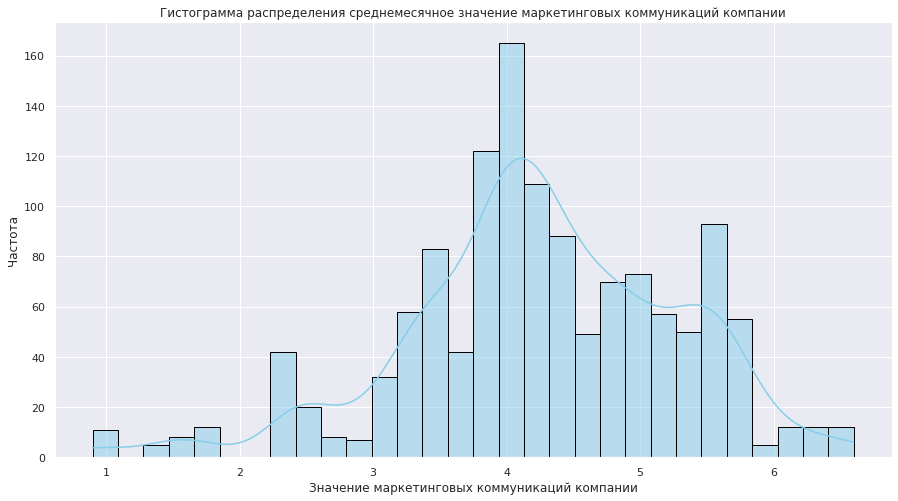

```python
sns.set_theme()
plt.figure(figsize=(15, 8))
sns.histplot(data=df_market['Маркет_актив_6_мес'], bins=30, color='skyblue', edgecolor='black', kde=True)
plt.title('Гистограмма распределения среднемесячное значение маркетинговых коммуникаций компании')
plt.xlabel('Значение маркетинговых коммуникаций компании')
plt.ylabel('Частота');
```

Рассмотрим признак `Маркет_актив_тек_мес` датасета *df_market*.

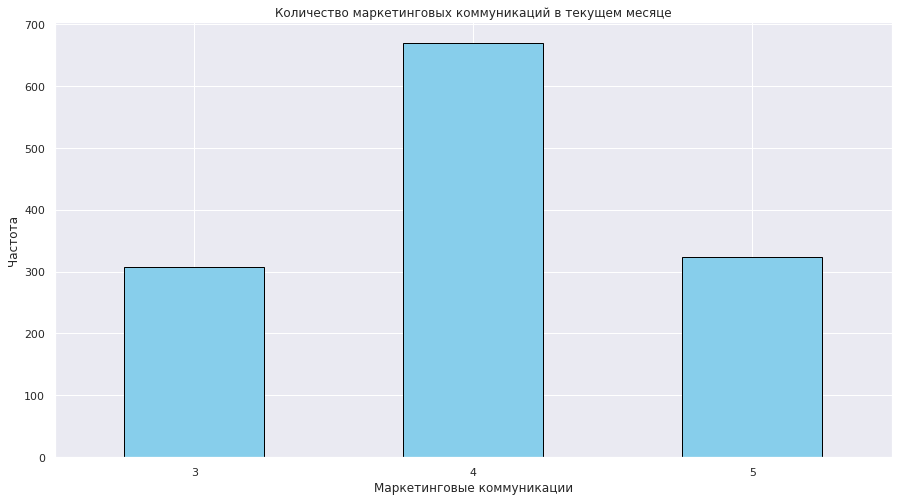

```python
plt.figure(figsize=(15, 8))
df_market.groupby('Маркет_актив_тек_мес').size().plot(kind='bar', color='skyblue', edgecolor='black', rot=0)
plt.title('Количество маркетинговых коммуникаций в текущем месяце')
plt.xlabel('Маркетинговые коммуникации')
plt.ylabel('Частота');
```

Рассмотрим признак `Длительность` датасета *df_market*.

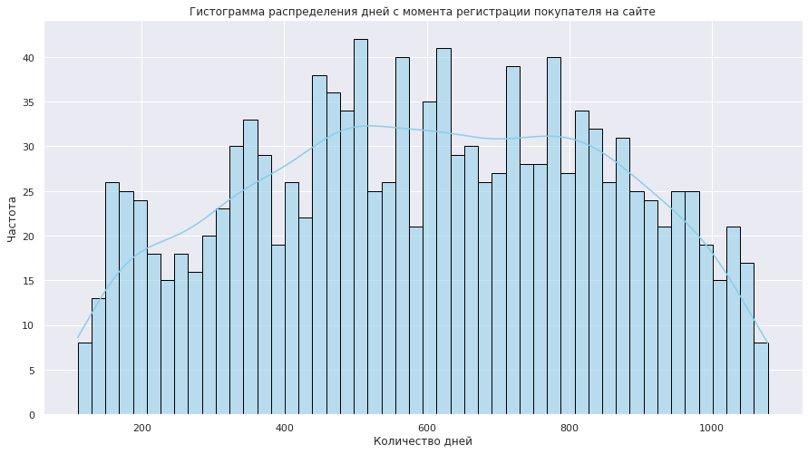

```python
plt.figure(figsize=(15, 8))
sns.histplot(data=df_market['Длительность'], bins=50, color='skyblue', edgecolor='black', kde=True)
plt.title('Гистограмма распределения дней с момента регистрации покупателя на сайте')
plt.xlabel('Количество дней')
plt.ylabel('Частота');
```

Рассмотрим признак `Акционные_покупки` датасета *df_market*.

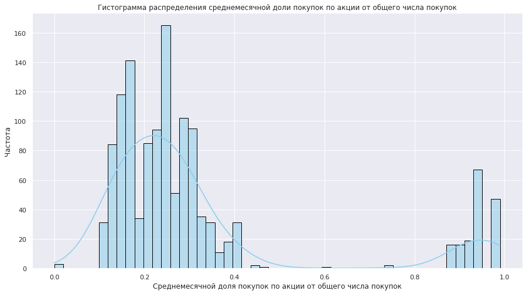

```python
plt.figure(figsize=(15, 8))
sns.histplot(data=df_market['Акционные_покупки'], bins=50, color='skyblue', edgecolor='black', kde=True)
plt.title('Гистограмма распределения среднемесячной доли покупок по акции от общего числа покупок')
plt.xlabel('Среднемесячной доля покупок по акции от общего числа покупок')
plt.ylabel('Частота');
```

Рассмотрим признак `Средний_просмотр_категорий_за_визит` датасета *df_market*.

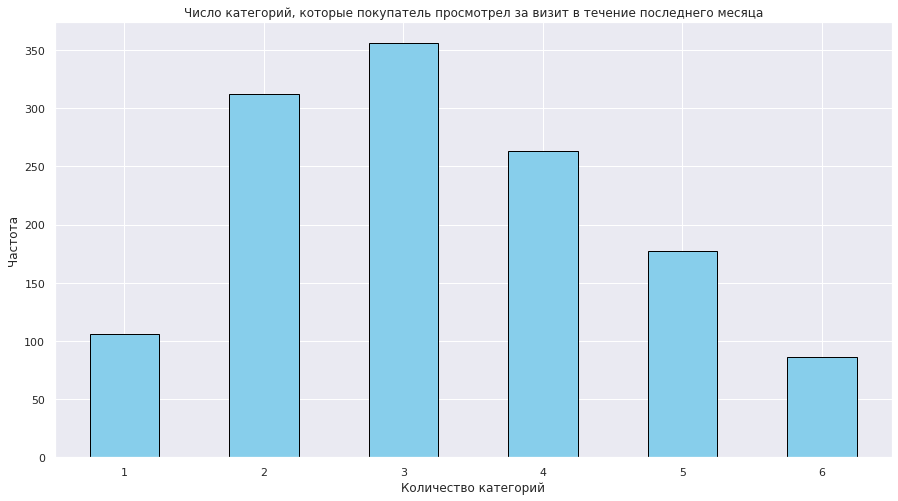

```python
plt.figure(figsize=(15, 8))
df_market.groupby('Средний_просмотр_категорий_за_визит').size().plot(kind='bar', color='skyblue', edgecolor='black', rot=0)
plt.title('Число категорий, которые покупатель просмотрел за визит в течение последнего месяца')
plt.xlabel('Количество категорий')
plt.ylabel('Частота');
```

Рассмотрим признак `Неоплаченные_продукты_штук_квартал` датасета *df_market*.

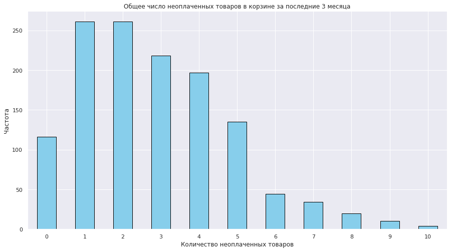

```python
plt.figure(figsize=(15, 8))
df_market.groupby('Неоплаченные_продукты_штук_квартал').size().plot(kind='bar', color='skyblue', edgecolor='black', rot=0)
plt.title('Общее число неоплаченных товаров в корзине за последние 3 месяца')
plt.xlabel('Количество неоплаченных товаров')
plt.ylabel('Частота');
```

Рассмотрим признак `Ошибка_сервиса` датасета *df_market*.

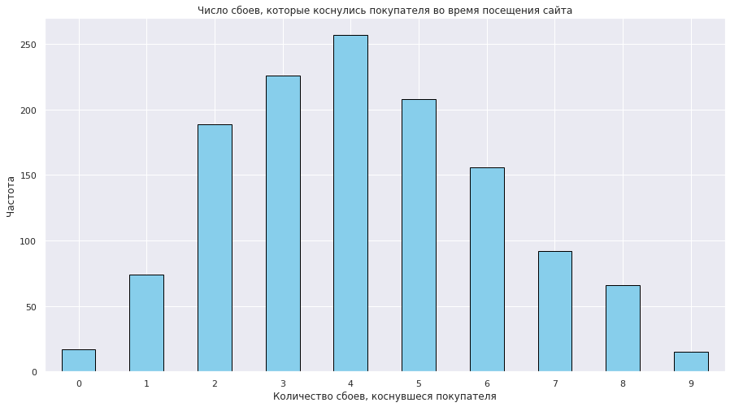

```python
plt.figure(figsize=(15, 8))
df_market.groupby('Ошибка_сервиса').size().plot(kind='bar', color='skyblue', edgecolor='black', rot=0)
plt.title('Число сбоев, которые коснулись покупателя во время посещения сайта')
plt.xlabel('Количество сбоев, коснувшеся покупателя')
plt.ylabel('Частота');
```

Рассмотрим признак `Страниц_за_визит` датасета *df_market*.

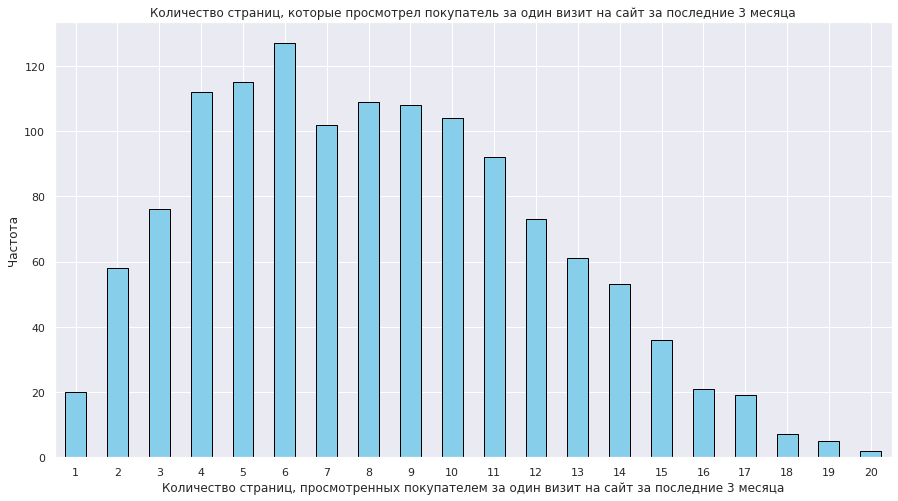

```python
plt.figure(figsize=(15, 8))
df_market.groupby('Страниц_за_визит').size().plot(kind='bar', color='skyblue', edgecolor='black', rot=0)
plt.title('Количество страниц, которые просмотрел покупатель за один визит на сайт за последние 3 месяца')
plt.xlabel('Количество страниц, просмотренных покупателем за один визит на сайт за последние 3 месяца')
plt.ylabel('Частота');
```

```python
df_market.drop('id', axis=1).describe()
```

|  | Маркет_актив_6_мес | Маркет_актив_тек_мес | Длительность | Акционные_покупки | Средний_просмотр_категорий_за_визит | Неоплаченные_продукты_штук_квартал | Ошибка_сервиса | Страниц_за_визит |
| --- | --- | --- | --- | --- | --- | --- | --- | --- |
| count | 1300.000000 | 1300.000000 | 1300.000000 | 1300.000000 | 1300.00000 | 1300.000000 | 1300.000000 | 1300.000000 |
| mean | 4.253769 | 4.011538 | 601.898462 | 0.319808 | 3.27000 | 2.840000 | 4.185385 | 8.176923 |
| std | 1.014814 | 0.696868 | 249.856289 | 0.249843 | 1.35535 | 1.971451 | 1.955298 | 3.978126 |
| min | 0.900000 | 3.000000 | 110.000000 | 0.000000 | 1.00000 | 0.000000 | 0.000000 | 1.000000 |
| 25% | 3.700000 | 4.000000 | 405.500000 | 0.170000 | 2.00000 | 1.000000 | 3.000000 | 5.000000 |
| 50% | 4.200000 | 4.000000 | 606.000000 | 0.240000 | 3.00000 | 3.000000 | 4.000000 | 8.000000 |
| 75% | 4.900000 | 4.000000 | 806.000000 | 0.300000 | 4.00000 | 4.000000 | 6.000000 | 11.000000 |
| max | 6.600000 | 5.000000 | 1079.000000 | 0.990000 | 6.00000 | 10.000000 | 9.000000 | 20.000000 |

- **Маркет_актив_6_мес**:
  - Данные распределены не нормально, есть скосы слева и справа;
  - Среднее значение - 4,25 шт., стандартное отклонение - 1,0 шт., что говорит о большом разбросе;
  - Минимальное значение - 0,9 шт., максимальное - 6,6 шт.;
  - Медиана равна 4,2 шт.;
  - 1 квартиль равен - 3,7 шт., 3 квартиль - 4,9 шт.
- **Маркет_актив_тек_мес**:
  - Среднее значение - 4,0 шт., станд.отклонение - 0,7 ед;
  - Минимальное значение в данных 3,0 ед., максимальное - 5,0 ед, медиана - 4,0 ед;
  - 1 квартиль равен 4,0 шт., 3 квартиль равен 4,0 шт.
- **Длительность**:
  - Характер распределения данных - не нормальный;
  - Среднее значение - 601,9 дней, станд.отклонение - 249,9 дней;
  - Минимальное значение в данных 110 дней, максимальное - 1079 дней, медиана - 606,0 дней;
  - 1 квартиль равен 405,5 дня, 3 квартиль равен 806,0 г.
- **Акционные_покупки**:
  - Среднее значение - 0,32 д.ед, станд.отклонение - 0,25 д.ед., что говорит о большом разбросе;
  - Минимальное значение в данных 0,0 д.ед, максимальное - 0,99 д.ед, медиана - 0,24 д.ед.;
  - 1 квартиль равен 0,17 д.ед, 3 квартиль равен 0,3 д.ед..
- **Средний_просмотр_категорий_за_визит**:
  - Среднее значение - 3,27, станд.отклонение - 1,36, что говорит о большом разбросе;
  - Минимальное значение в данных 1,0, максимальное - 6,0, медиана - 3,0;
  - 1 квартиль равен 2,0, 3 квартиль равен 4,0.
- **Неоплаченные_продукты_штук_квартал**:
  - Среднее значение - 2,84, станд.отклонение - 1,97;
  - Минимальное значение в данных 0,0, максимальное - 10,0, медиана - 3,0;
  - 1 квартиль равен 1,0, 3 квартиль равен 4,0.
- **Ошибка_сервиса**:
  - Среднее значение - 4,2, станд.отклонение - 1,96;
  - Минимальное значение в данных 0,0, максимальное - 9,0, медиана - 4,0;
  - 1 квартиль равен 3,0, 3 квартиль равен 6,0.
- **Страниц_за_визит**:
  - Среднее значение - 8,2, станд.отклонение - 3,98;
  - Минимальное значение в данных 1,0, максимальное - 20,0, медиана - 8,0;
  - 1 квартиль равен 5,0, 3 квартиль равен 11,0.

Для неколичественных переменных построим столбчатый график и круговую диаграмму.

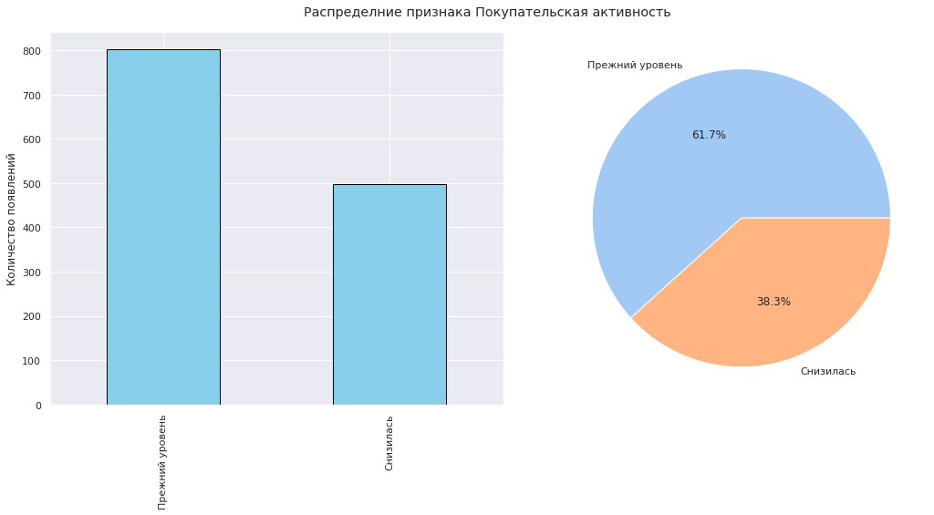

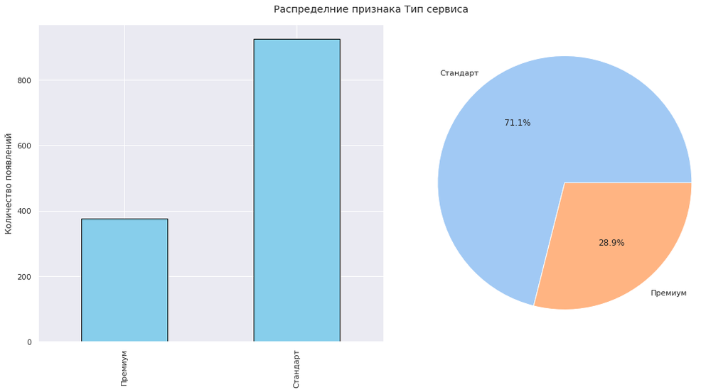

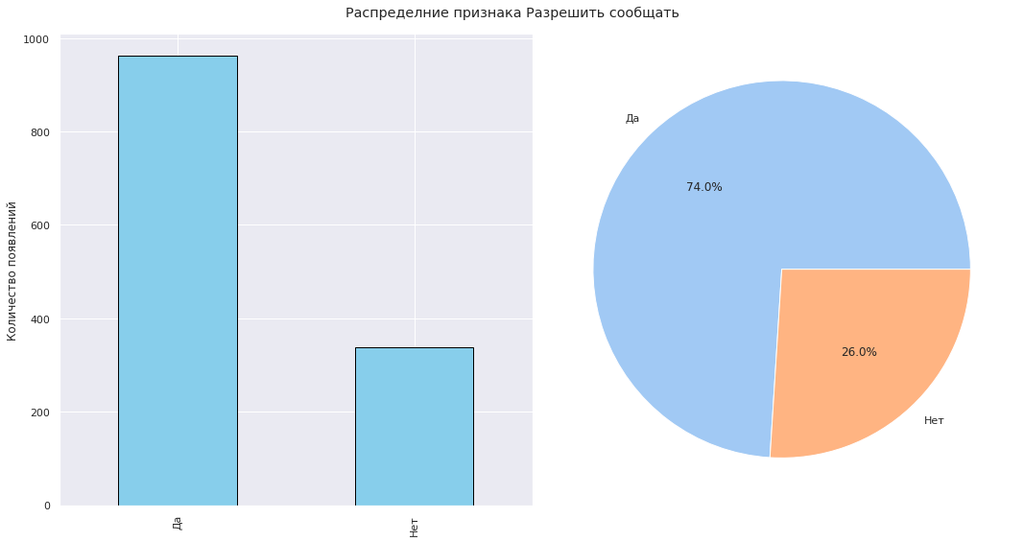

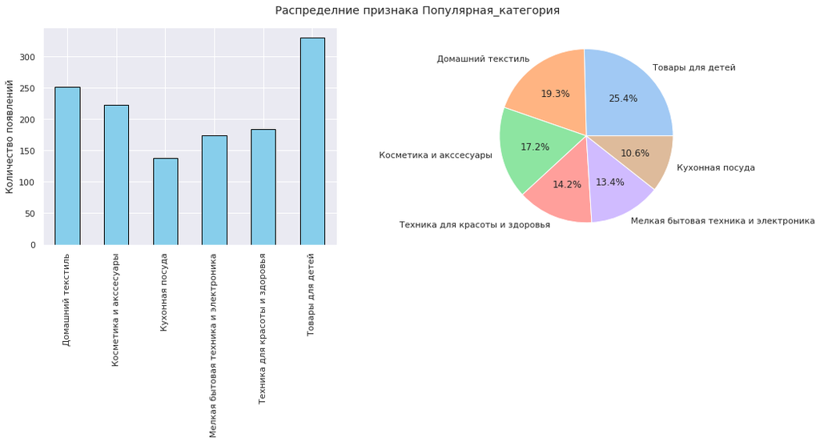

```python
sns.set_theme(palette='pastel')
for column in df_market.select_dtypes(exclude='number').columns:
    fig, axes = plt.subplots(1, 2, figsize=(15, 8))
    plt.suptitle(f'Распределние признака {column}')
    df_market.groupby(column).size().plot.bar(ax=axes[0], color='skyblue',
                                              edgecolor='black', xlabel='', ylabel='Количество появлений')
    df_market[column].value_counts().plot.pie(ax=axes[1], autopct='%.1f%%', ylabel='')
    fig.tight_layout();
```

- **Покупательская активность** : У 38,3% покупателей магазина уменьшилась покупательская активность.
- **Тип сервиса** : У 71,1% покупателей стандартный тип сервиса, у остальных - премиум.
- **Разрешить сообщать** : 74% покупателей дали согласие на рассылкудополнительные предложений о товарах.
- **Популярная_категория** : Самый популярные товары покупателей - Товары для детей (25,4%), далее идёт домашний текстиль (19,3%), косметика и акссесуары (17,2%) и другие.

### Датасет *df_market_money*

Рассмотрим датасет *df_market_money*.

```python
df_market_money.head()
```

|  | id | Период | Выручка |
| --- | --- | --- | --- |
| 0 | 215348 | препредыдущий_месяц | 0.0 |
| 1 | 215348 | текущий_месяц | 3293.1 |
| 2 | 215348 | предыдущий_месяц | 0.0 |
| 3 | 215349 | препредыдущий_месяц | 4472.0 |
| 4 | 215349 | текущий_месяц | 4971.6 |

Построим гистограмму распределения выручки по данным.

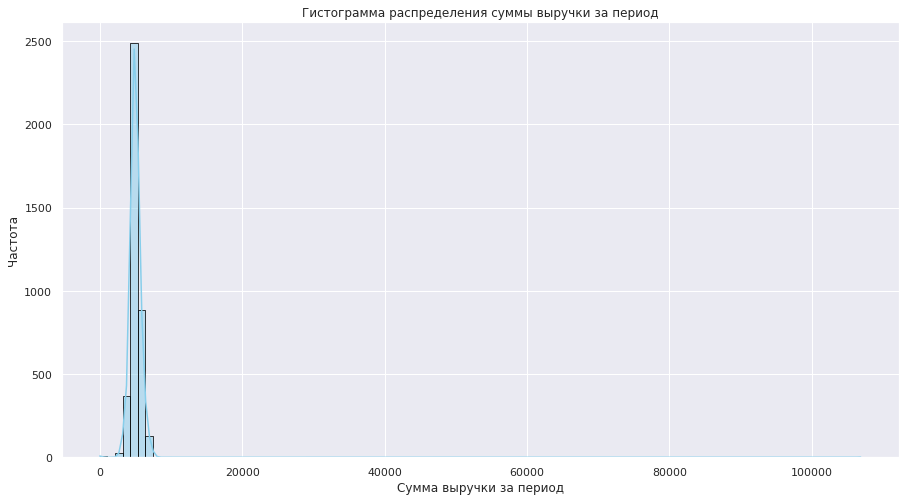

```python
plt.figure(figsize=(15, 8))
sns.histplot(data=df_market_money['Выручка'], bins=100, color='skyblue', edgecolor='black', kde=True)
plt.title('Гистограмма распределения суммы выручки за период')
plt.xlabel('Cумма выручки за период')
plt.ylabel('Частота');
```

Отберем для нашего анализа только клиентов, которые приносили компании выручку за последние 3 месяца, то есть тех, от которых компания получала ненулевую выручка за все последние 3 месяца.

Cначала, рассмотрим значения с нулевой выручкой для магазина.

```python
df_market_money.query('Выручка == 0')
```

|  | id | Период | Выручка |
| --- | --- | --- | --- |
| 0 | 215348 | препредыдущий_месяц | 0.0 |
| 2 | 215348 | предыдущий_месяц | 0.0 |
| 28 | 215357 | препредыдущий_месяц | 0.0 |
| 29 | 215357 | предыдущий_месяц | 0.0 |
| 34 | 215359 | предыдущий_месяц | 0.0 |
| 35 | 215359 | препредыдущий_месяц | 0.0 |

Видим, что нулевая выручка для магазина была зафиксирована 6 раз, и всего от 3 клиентов. Для нашего дальнейшего исследования удалим из данных все записи об этих клиентах.

Так как на каждого клиента в датасете *df_market_money* приходится 3 записи, таким образом удалим 9 записей.

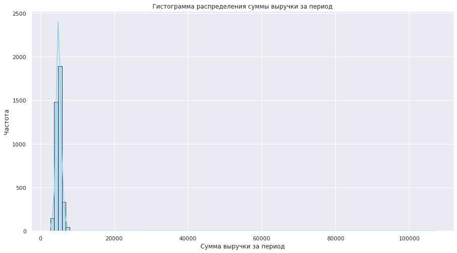

```python
df_market_money = df_market_money.query('id not in [215348, 215357, 215359]')
plt.figure(figsize=(15, 8))
sns.histplot(data=df_market_money['Выручка'], bins=100, color='skyblue', edgecolor='black', kde=True)
plt.title('Гистограмма распределения суммы выручки за период')
plt.xlabel('Cумма выручки за период')
plt.ylabel('Частота');
```

Видим, что в данных есть выбивающиеся значения, рассмотрим их подробнее.

```python
df_market_money.query('Выручка > 8000')
```

|  | id | Период | Выручка |
| --- | --- | --- | --- |
| 98 | 215380 | текущий_месяц | 106862.2 |

В данных лишь один выброс, для того, чтобы при объединении таблиц не было пропусков, вместо удаления заменим это значение выручки на медианное и заново построим гистограмму распределения и ящик с усами.

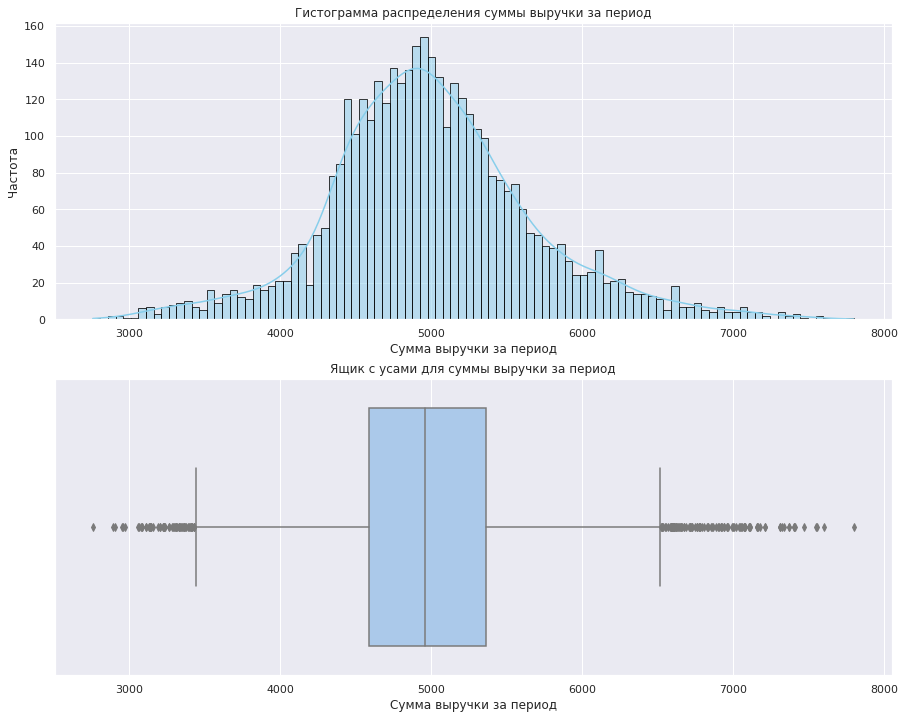

```python
df_market_money.loc[df_market_money['Выручка'] > 8000, 'Выручка'] = df_market_money['Выручка'].median()
fig, axes = plt.subplots(2, 1, figsize=(15, 12))
sns.histplot(data=df_market_money['Выручка'], ax=axes[0], bins=100,
             color='skyblue', edgecolor='black', kde=True)
axes[0].set_title('Гистограмма распределения суммы выручки за период')
axes[0].set_xlabel('Cумма выручки за период')
axes[0].set_ylabel('Частота')
sns.boxplot(x=df_market_money['Выручка'], ax=axes[1])
axes[1].set_title('\nЯщик с усами для суммы выручки за период')
axes[1].set_xlabel('Cумма выручки за период');
```

```python
df_market_money.drop('id', axis=1).describe()
```

|  | Выручка |
| --- | --- |
| count | 3891.000000 |
| mean | 5007.529427 |
| std | 679.148872 |
| min | 2758.700000 |
| 25% | 4592.000000 |
| 50% | 4959.000000 |
| 75% | 5363.000000 |
| max | 7799.400000 |

**Выручка**:

- Данные распределены нормально;
- Среднее значение - 5007,53 у.е., стандартное отклонение - 679,1 у.е.;
- Минимальное значение - 2758,7 у.е., максимальное - 7799,4 у.е.;
- Медиана равна 4959,0 у.е.;
- 1 квартиль равен - 4592,0 у.е., 3 квартиль - 5363,0 у.е.

Для столбца `Период` построим частотную диаграмму и круговую диаграмму.

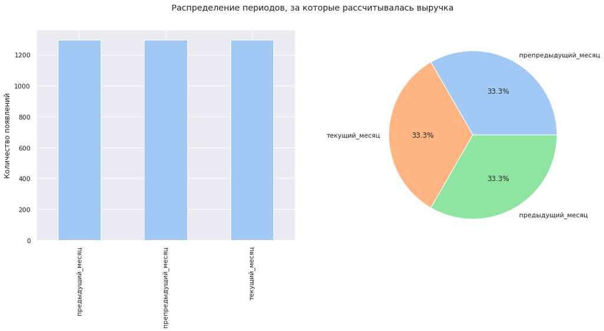

```python
fig, axes = plt.subplots(1, 2, figsize=(15, 8))
plt.suptitle('Распределение периодов, за которые рассчитывалась выручка\n')
df_market_money.groupby('Период').size().plot.bar(ax=axes[0], ylabel='Количество появлений', xlabel='')
df_market_money['Период'].value_counts().plot.pie(ax=axes[1], ylabel='', autopct='%.1f%%')
fig.tight_layout();
```

### Датасет *df_time*

```python
df_time.head()
```

|  | id | Период | Минут |
| --- | --- | --- | --- |
| 0 | 215348 | текущий_месяц | 14 |
| 1 | 215348 | предыдущий_месяц | 13 |
| 2 | 215349 | текущий_месяц | 10 |
| 3 | 215349 | предыдущий_месяц | 12 |
| 4 | 215350 | текущий_месяц | 13 |

Рассмотрим признак `Период` датасета *df_time*.

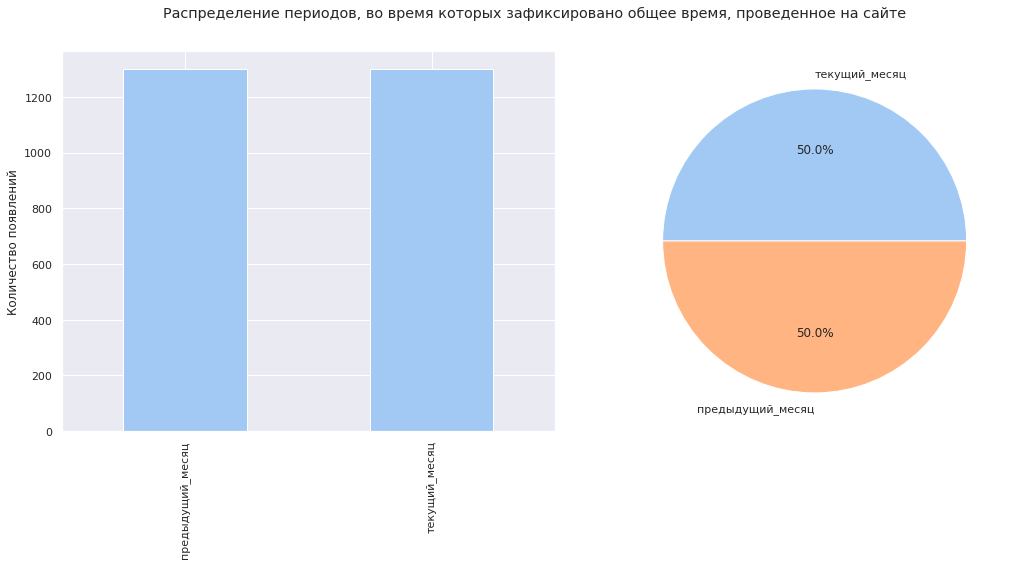

```python
fig, axes = plt.subplots(1, 2, figsize=(15, 8))
plt.suptitle('Распределение периодов, во время которых зафиксировано общее время, проведенное на сайте\n')
df_time.groupby('Период').size().plot.bar(ax=axes[0], ylabel='Количество появлений', xlabel='')
df_time['Период'].value_counts().plot.pie(ax=axes[1], ylabel='', autopct='%.1f%%')
fig.tight_layout();
```

В датасете *df_time* каждому клиенту соответствуют две записи за текущий и предыдущий месяц.

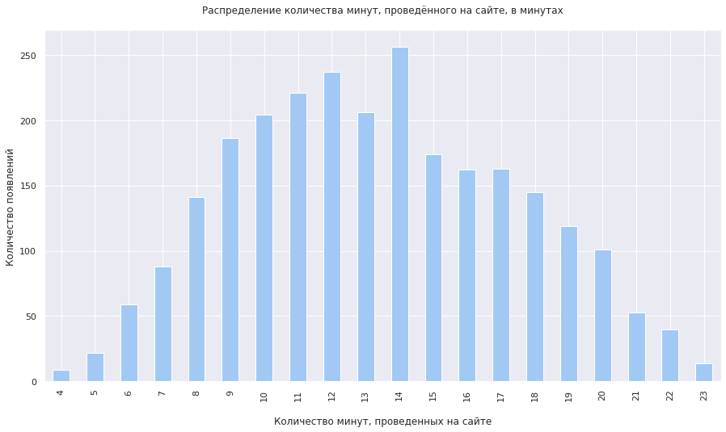

```python
df_time.groupby('Минут').size().plot.bar(
    ylabel='Количество появлений',
    xlabel='\nКоличество минут, проведенных на сайте',
    figsize=(15, 8),
    title='Распределение количества минут, проведённого на сайте, в минутах\n', x='');
```

### Датасет *df_money*

```python
df_money.head()
```

|  | id | Прибыль |
| --- | --- | --- |
| 0 | 215348 | 0.98 |
| 1 | 215349 | 4.16 |
| 2 | 215350 | 3.13 |
| 3 | 215351 | 4.87 |
| 4 | 215352 | 4.21 |

Рассмотрим признак `Прибыль` датасета *df_money*.

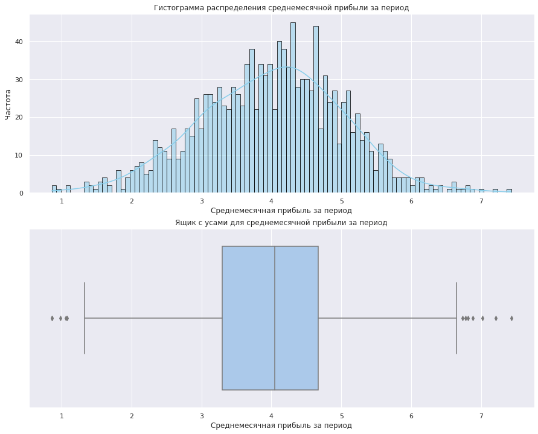

```python
fig, axes = plt.subplots(2, 1, figsize=(15, 12))
sns.histplot(data=df_money['Прибыль'], ax=axes[0], bins=100,
             color='skyblue', edgecolor='black', kde=True)
axes[0].set_title('Гистограмма распределения среднемесячной прибыли за период')
axes[0].set_xlabel('Среднемесячная прибыль за период')
axes[0].set_ylabel('Частота')
sns.boxplot(x=df_money['Прибыль'], ax=axes[1])
axes[1].set_title('\nЯщик с усами для среднемесячной прибыли за период')
axes[1].set_xlabel('Среднемесячная прибыль за период');
```

```python
df_money.drop('id', axis=1).describe()
```

|  | Прибыль |
| --- | --- |
| count | 1300.000000 |
| mean | 3.996631 |
| std | 1.013722 |
| min | 0.860000 |
| 25% | 3.300000 |
| 50% | 4.045000 |
| 75% | 4.670000 |
| max | 7.430000 |

**Прибыль**:

- Данные распределены нормально;
- Среднее значение - 4,0 у.е., стандартное отклонение - 1,01 у.е.;
- Минимальное значение - 0,86 у.е., максимальное - 7,43 у.е.;
- Медиана равна 4,05 у.е.;
- 1 квартиль равен - 3,3 у.е., 3 квартиль - 4,67 у.е.

## Объединение таблиц

Перед объединением создадим две сводные таблицы из датасетов *df_time* и *df_market_money*, в которых сгруппируем данные по `id`.

```python
df_pivot_time = df_time.pivot_table(index='id', columns='Период', values='Минут').rename(columns={
    'предыдущий_месяц': 'Минуты_предыдущий_месяц',
    'текущий_месяц': 'Минуты_текущий_месяц'})
df_pivot_time.head()
```

| Период id | Минуты_предыдущий_месяц | Минуты_текущий_месяц |
| --- | --- | --- |
| 215348 | 13 | 14 |
| 215349 | 12 | 10 |
| 215350 | 8 | 13 |
| 215351 | 11 | 13 |
| 215352 | 8 | 11 |

```python
df_pivot_market_money = df_market_money.pivot_table(index='id', columns='Период', values='Выручка').rename(columns={
    'предыдущий_месяц': 'Выручка_предыдущий_месяц',
    'текущий_месяц': 'Выручка_текущий_месяц',
    'препредыдущий_месяц': 'Выручка_препредыдущий_месяц'})
df_pivot_market_money.head()
```

| Период id | Выручка_предыдущий_месяц | Выручка_препредыдущий_месяц | Выручка_текущий_месяц |
| --- | --- | --- | --- |
| 215349 | 5216.0 | 4472.0 | 4971.6 |
| 215350 | 5457.5 | 4826.0 | 5058.4 |
| 215351 | 6158.0 | 4793.0 | 6610.4 |
| 215352 | 5807.5 | 4594.0 | 5872.5 |
| 215353 | 4738.5 | 5124.0 | 5388.5 |

```python
df = df_market.merge(df_pivot_market_money, on='id')
df = df.merge(df_pivot_time, on='id')
df.head()
```

|  | id | Покупательская активность | Тип сервиса | Разрешить сообщать | Маркет_актив_6_мес | Маркет_актив_тек_мес | Длительность | Акционные_покупки | Популярная_категория | Средний_просмотр_категорий_за_визит | Неоплаченные_продукты_штук_квартал | Ошибка_сервиса | Страниц_за_визит | Выручка_предыдущий_месяц | Выручка_препредыдущий_месяц | Выручка_текущий_месяц | Минуты_предыдущий_месяц | Минуты_текущий_месяц |
| --- | --- | --- | --- | --- | --- | --- | --- | --- | --- | --- | --- | --- | --- | --- | --- | --- | --- | --- |
| 0 | 215349 | Снизилась | Премиум | Да | 4.4 | 4 | 819 | 0.75 | Товары для детей | 4 | 4 | 2 | 5 | 5216.0 | 4472.0 | 4971.6 | 12 | 10 |
| 1 | 215350 | Снизилась | Стандарт | Нет | 4.9 | 3 | 539 | 0.14 | Домашний текстиль | 5 | 2 | 1 | 5 | 5457.5 | 4826.0 | 5058.4 | 8 | 13 |
| 2 | 215351 | Снизилась | Стандарт | Да | 3.2 | 5 | 896 | 0.99 | Товары для детей | 5 | 0 | 6 | 4 | 6158.0 | 4793.0 | 6610.4 | 11 | 13 |
| 3 | 215352 | Снизилась | Стандарт | Нет | 5.1 | 3 | 1064 | 0.94 | Товары для детей | 3 | 2 | 3 | 2 | 5807.5 | 4594.0 | 5872.5 | 8 | 11 |
| 4 | 215353 | Снизилась | Стандарт | Да | 3.3 | 4 | 762 | 0.26 | Домашний текстиль | 4 | 1 | 1 | 4 | 4738.5 | 5124.0 | 5388.5 | 10 | 10 |

Проверим полученный объединенный датасет на наличие пропусков.

```python
df.isna().sum()
```

```
id                                     0
Покупательская активность              0
Тип сервиса                            0
Разрешить сообщать                     0
Маркет_актив_6_мес                     0
Маркет_актив_тек_мес                   0
Длительность                           0
Акционные_покупки                      0
Популярная_категория                   0
Средний_просмотр_категорий_за_визит    0
Неоплаченные_продукты_штук_квартал     0
Ошибка_сервиса                         0
Страниц_за_визит                       0
Выручка_предыдущий_месяц               0
Выручка_препредыдущий_месяц            0
Выручка_текущий_месяц                  0
Минуты_предыдущий_месяц                0
Минуты_текущий_месяц                   0
dtype: int64
```

Пропусков нет, с таблицей все в порядке.

**Вывод:** В ходе объединения были соединены датасеты *df_market*, *df_market_money* и *df_time*. В полученной таблице пропусков не обнаружено.

## Корелляционный анализ

Рассчитаем значения корреляции хи-квадрат между признаками:

```
interval columns not set, guessing: ['Маркет_актив_6_мес', 'Маркет_актив_тек_мес', 'Длительность', 'Акционные_покупки', 'Средний_просмотр_категорий_за_визит', 'Неоплаченные_продукты_штук_квартал', 'Ошибка_сервиса', 'Страниц_за_визит', 'Выручка_предыдущий_месяц', 'Выручка_препредыдущий_месяц', 'Выруч…
```

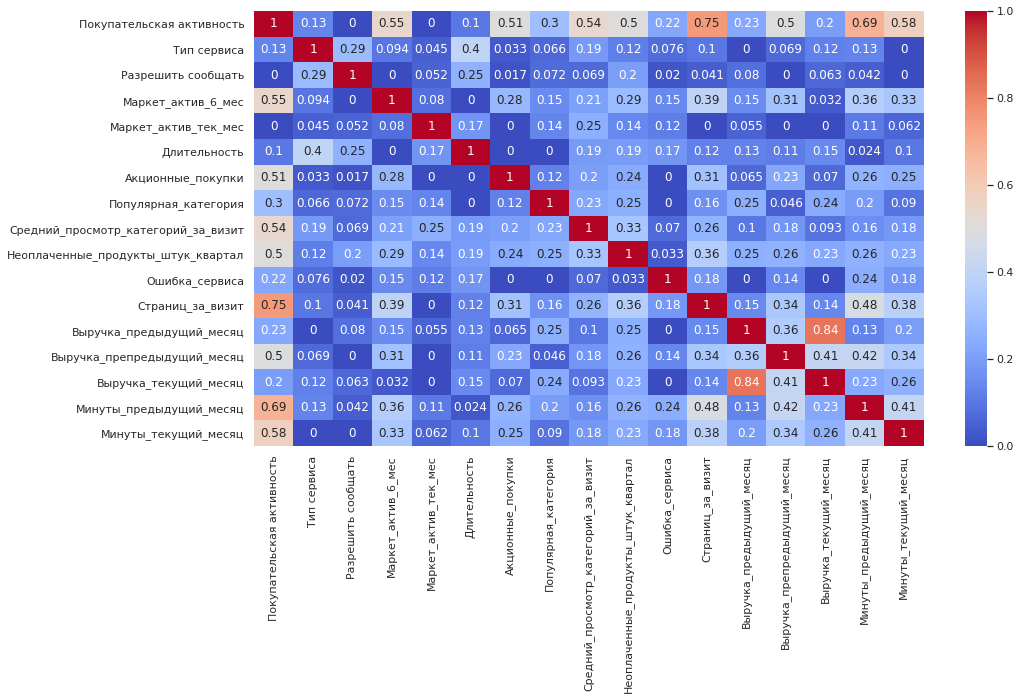

```python
plt.figure(figsize=(15, 8))
sns.heatmap(df.drop('id', axis=1).phik_matrix(), annot=True, cmap='coolwarm');
```

**Вывод:** Значения корреляции хи-квадрат обнаружены, в основном, с целевым признаком, из наиболее коррелирующих признаков выделим `Страниц_за_визит`, `Минуты_предыдущий_месяц` и `Минуты_текущий_месяц`. Из остальных признаков выделим корреляцию между признаками `Выручка_текущий_месяц` и `Выручка_предыдущий_месяц`.

Мультиколлинеарности в данных не обнаружено, т.к. все значения корреляции хи-квадрат меньше 0,9.

## Использование пайплайнов

```python
df.head()
```

|  | id | Покупательская активность | Тип сервиса | Разрешить сообщать | Маркет_актив_6_мес | Маркет_актив_тек_мес | Длительность | Акционные_покупки | Популярная_категория | Средний_просмотр_категорий_за_визит | Неоплаченные_продукты_штук_квартал | Ошибка_сервиса | Страниц_за_визит | Выручка_предыдущий_месяц | Выручка_препредыдущий_месяц | Выручка_текущий_месяц | Минуты_предыдущий_месяц | Минуты_текущий_месяц |
| --- | --- | --- | --- | --- | --- | --- | --- | --- | --- | --- | --- | --- | --- | --- | --- | --- | --- | --- |
| 0 | 215349 | Снизилась | Премиум | Да | 4.4 | 4 | 819 | 0.75 | Товары для детей | 4 | 4 | 2 | 5 | 5216.0 | 4472.0 | 4971.6 | 12 | 10 |
| 1 | 215350 | Снизилась | Стандарт | Нет | 4.9 | 3 | 539 | 0.14 | Домашний текстиль | 5 | 2 | 1 | 5 | 5457.5 | 4826.0 | 5058.4 | 8 | 13 |
| 2 | 215351 | Снизилась | Стандарт | Да | 3.2 | 5 | 896 | 0.99 | Товары для детей | 5 | 0 | 6 | 4 | 6158.0 | 4793.0 | 6610.4 | 11 | 13 |
| 3 | 215352 | Снизилась | Стандарт | Нет | 5.1 | 3 | 1064 | 0.94 | Товары для детей | 3 | 2 | 3 | 2 | 5807.5 | 4594.0 | 5872.5 | 8 | 11 |
| 4 | 215353 | Снизилась | Стандарт | Да | 3.3 | 4 | 762 | 0.26 | Домашний текстиль | 4 | 1 | 1 | 4 | 4738.5 | 5124.0 | 5388.5 | 10 | 10 |

Для подготовки данных к моделированию закодируем целевой признак значениями 0 и 1, а также уберем недающий значимой информации столбец `id` в индекс.

```python
df['Покупательская активность'] = df['Покупательская активность'].apply(lambda x: 1 if x=='Снизилась' else 0).astype('int64')
df.set_index('id', inplace=True)
df.head()
```

| id | Покупательская активность | Тип сервиса | Разрешить сообщать | Маркет_актив_6_мес | Маркет_актив_тек_мес | Длительность | Акционные_покупки | Популярная_категория | Средний_просмотр_категорий_за_визит | Неоплаченные_продукты_штук_квартал | Ошибка_сервиса | Страниц_за_визит | Выручка_предыдущий_месяц | Выручка_препредыдущий_месяц | Выручка_текущий_месяц | Минуты_предыдущий_месяц | Минуты_текущий_месяц |
| --- | --- | --- | --- | --- | --- | --- | --- | --- | --- | --- | --- | --- | --- | --- | --- | --- | --- |
| 215349 | 1 | Премиум | Да | 4.4 | 4 | 819 | 0.75 | Товары для детей | 4 | 4 | 2 | 5 | 5216.0 | 4472.0 | 4971.6 | 12 | 10 |
| 215350 | 1 | Стандарт | Нет | 4.9 | 3 | 539 | 0.14 | Домашний текстиль | 5 | 2 | 1 | 5 | 5457.5 | 4826.0 | 5058.4 | 8 | 13 |
| 215351 | 1 | Стандарт | Да | 3.2 | 5 | 896 | 0.99 | Товары для детей | 5 | 0 | 6 | 4 | 6158.0 | 4793.0 | 6610.4 | 11 | 13 |
| 215352 | 1 | Стандарт | Нет | 5.1 | 3 | 1064 | 0.94 | Товары для детей | 3 | 2 | 3 | 2 | 5807.5 | 4594.0 | 5872.5 | 8 | 11 |
| 215353 | 1 | Стандарт | Да | 3.3 | 4 | 762 | 0.26 | Домашний текстиль | 4 | 1 | 1 | 4 | 4738.5 | 5124.0 | 5388.5 | 10 | 10 |

```python
X = df.drop('Покупательская активность', axis=1)
y = df['Покупательская активность']

X_train, X_test, y_train, y_test = train_test_split(X, y, test_size=TEST_SIZE, random_state=RANDOM_STATE, stratify=y)
```

```python
ohe_columns = ['Разрешить сообщать',
               'Популярная_категория']

ord_columns = ['Тип сервиса']

num_columns = ['Маркет_актив_6_мес',
              'Маркет_актив_тек_мес',
              'Длительность',
              'Акционные_покупки',
              'Средний_просмотр_категорий_за_визит',
              'Неоплаченные_продукты_штук_квартал',
              'Ошибка_сервиса',
              'Страниц_за_визит',
              'Выручка_предыдущий_месяц',
              'Выручка_препредыдущий_месяц',
              'Выручка_текущий_месяц',
              'Минуты_предыдущий_месяц',
              'Минуты_текущий_месяц']
```

```python
# SimpleImputer + OHE
ohe_pipe = Pipeline(
    [('simpleImputer_ohe', SimpleImputer(missing_values=np.nan, strategy='most_frequent')),
     ('ohe', OneHotEncoder(drop='first', handle_unknown='ignore', sparse=False))
    ]
)
# SimpleImputer + OE
ord_pipe = Pipeline(
    [('simpleImputer_before_ord', SimpleImputer(missing_values=np.nan, strategy='most_frequent')),
     ('ord',  OrdinalEncoder(categories=[
                    ['Стандарт', 'Премиум']],
                handle_unknown='use_encoded_value', unknown_value=np.nan)),
     ('simpleImputer_after_ord', SimpleImputer(missing_values=np.nan, strategy='most_frequent'))
    ]
)
```

```python
data_preprocessor = ColumnTransformer(
    [('ohe', ohe_pipe, ohe_columns),
     ('ord', ord_pipe, ord_columns),
     ('num', MinMaxScaler(), num_columns),
    ],
    remainder='passthrough'
)
```

```python
pipe_final = Pipeline([
    ('preprocessor', data_preprocessor),
    ('models', DecisionTreeClassifier(random_state=RANDOM_STATE))
])
```

```python
param_grid = [
    # словарь для модели DecisionTreeClassifier()
    {
        'models': [DecisionTreeClassifier(random_state=RANDOM_STATE)],
        'models__max_depth': range(2, 6),
        'models__max_features': range(2, 6),
        'preprocessor__num': [StandardScaler(), MinMaxScaler(), 'passthrough']
    },

    # словарь для модели KNeighborsClassifier()
    {
        'models': [KNeighborsClassifier()],
        'models__n_neighbors': range(2, 6),
        'preprocessor__num': [StandardScaler(), MinMaxScaler(), 'passthrough']
    },

    # словарь для модели LogisticRegression()
    {
        'models': [LogisticRegression(
            random_state=RANDOM_STATE,
            solver='liblinear',
            penalty='l1'
        )],
        'models__C': range(1, 5),
        'preprocessor__num': [StandardScaler(), MinMaxScaler(), 'passthrough']
    },

    # словарь для модели SVC()
    {
        'models': [SVC(
            random_state=RANDOM_STATE,
            kernel='poly',
            probability=True
        )],
        'models__C': range(1, 5),
        'models__degree': range(2, 4),
        'preprocessor__num': [StandardScaler(), MinMaxScaler(), 'passthrough']
    }
]
```

В качестве метрики выберем ROC-AUC, т.к. имеется дизбаланс классов и нам необходимо оценить качество работы модели вне зависимости от выбранного порога вероятности.

```python
randomized_search = RandomizedSearchCV(
    pipe_final,
    param_grid,
    n_iter=40,
    cv=5,
    scoring='roc_auc',
    n_jobs=-1
)
randomized_search.fit(X_train, y_train)
```

```
RandomizedSearchCV(cv=5,
                   estimator=Pipeline(steps=[('preprocessor',
                                              ColumnTransformer(remainder='passthrough',
                                                                transformers=[('ohe',
                                                                               Pipeline(steps=[('simpleImputer_ohe',
                                                                                                SimpleImputer(strategy='most_frequent')),
                                                                                               ('ohe',
                                                                                                OneHotEncoder(drop='first',
                                                                                                              handle_unknown='ignore',
                                                                                                              sparse=False))]),
                                                                               ['Разрешить '
                                                                                'сообщать',
                                                                                'Популярная_категория']),
                                                                              ('ord',
                                                                               Pipeline(step...
                                        {'models': [LogisticRegression(penalty='l1',
                                                                       random_state=42,
                                                                       solver='liblinear')],
                                         'models__C': range(1, 5),
                                         'preprocessor__num': [StandardScaler(),
                                                               MinMaxScaler(),
                                                               'passthrough']},
                                        {'models': [SVC(C=2, kernel='poly',
                                                        probability=True,
                                                        random_state=42)],
                                         'models__C': range(1, 5),
                                         'models__degree': range(2, 4),
                                         'preprocessor__num': [StandardScaler(),
                                                               MinMaxScaler(),
                                                               'passthrough']}],
                   scoring='roc_auc')
```

```python
randomized_search.best_estimator_
```

```
Pipeline(steps=[('preprocessor',
                 ColumnTransformer(remainder='passthrough',
                                   transformers=[('ohe',
                                                  Pipeline(steps=[('simpleImputer_ohe',
                                                                   SimpleImputer(strategy='most_frequent')),
                                                                  ('ohe',
                                                                   OneHotEncoder(drop='first',
                                                                                 handle_unknown='ignore',
                                                                                 sparse=False))]),
                                                  ['Разрешить сообщать',
                                                   'Популярная_категория']),
                                                 ('ord',
                                                  Pipeline(steps=[('simpleImputer_before_ord',
                                                                   Simpl...
                                                   'Маркет_актив_тек_мес',
                                                   'Длительность',
                                                   'Акционные_покупки',
                                                   'Средний_просмотр_категорий_за_визит',
                                                   'Неоплаченные_продукты_штук_квартал',
                                                   'Ошибка_сервиса',
                                                   'Страниц_за_визит',
                                                   'Выручка_предыдущий_месяц',
                                                   'Выручка_препредыдущий_месяц',
                                                   'Выручка_текущий_месяц',
                                                   'Минуты_предыдущий_месяц',
                                                   'Минуты_текущий_месяц'])])),
                ('models',
                 SVC(C=2, kernel='poly', probability=True, random_state=42))])
```

```python
print('Лучшая модель и её параметры:\n\n', randomized_search.best_estimator_)
print ('Метрика лучшей модели на тренировочной выборке:', round(randomized_search.best_score_, 3))
```

```
Лучшая модель и её параметры:

 Pipeline(steps=[('preprocessor',
                 ColumnTransformer(remainder='passthrough',
                                   transformers=[('ohe',
                                                  Pipeline(steps=[('simpleImputer_ohe',
                                                                   SimpleImputer(strategy='most_frequent')),
                                                                  ('ohe',
                                                                   OneHotEncoder(drop='first',
                                                                                 handle_unknown='ignore',
                                                                                 sparse=False))]),
                                                  ['Разрешить сообщать',
                                                   'Популярная_категория']),
                                                 ('ord',
                                                  Pipeline(steps=[('simpleImputer_before_ord',
                                                                   Simpl...
                                                   'Маркет_актив_тек_мес',
                                                   'Длительность',
                                                   'Акционные_покупки',
                                                   'Средний_просмотр_категорий_за_визит',
                                                   'Неоплаченные_продукты_штук_квартал',
                                                   'Ошибка_сервиса',
                                                   'Страниц_за_визит',
                                                   'Выручка_предыдущий_месяц',
                                                   'Выручка_препредыдущий_месяц',
                                                   'Выручка_текущий_месяц',
                                                   'Минуты_предыдущий_месяц',
                                                   'Минуты_текущий_месяц'])])),
                ('models',
                 SVC(C=2, kernel='poly', probability=True, random_state=42))])
Метрика лучшей модели на тренировочной выборке: 0.907
```

```python
y_test_pred = randomized_search.predict(X_test)
y_test_proba = randomized_search.predict_proba(X_test)
print(f'Метрика ROC-AUC на тестовой выборке: {round(roc_auc_score(y_test, y_test_proba[:,1]), 3)}')
```

```
Метрика ROC-AUC на тестовой выборке: 0.909
```

```python
print(f'Метрика F1-score на тестовой выборке: {round(f1_score(y_test, y_test_pred, average="binary"), 3)}')
```

```
Метрика F1-score на тестовой выборке: 0.836
```

## Анализ важности признаков

Для анализа важности признаков воспользуемся SHAP значениями. Т.к SVC модель имеет полиномиальное ядро, используем KernelExplainer, что существенно увеличит время вычислений, поэтому ограничим входную выборку 50 записями.

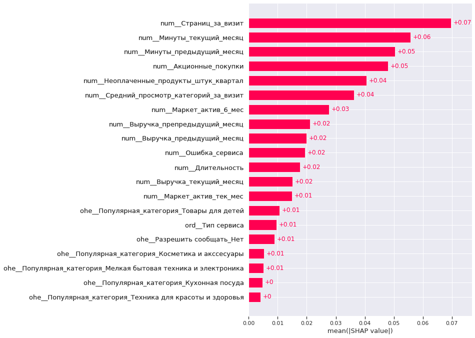

```
None
```

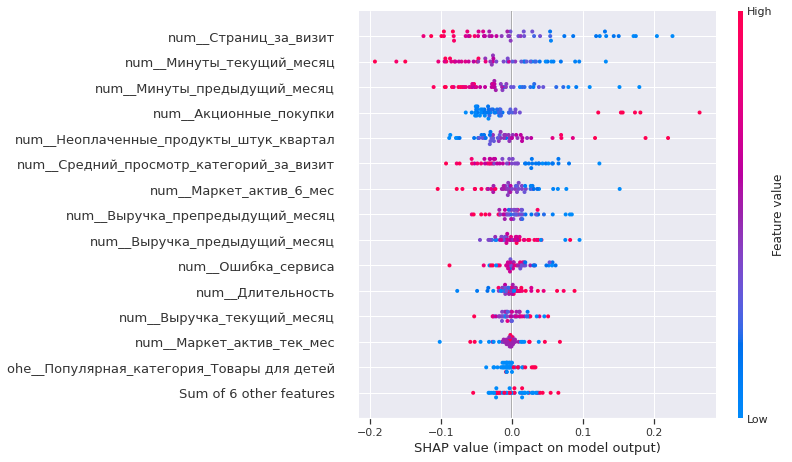

```python
X_train_2 = randomized_search.best_estimator_.named_steps['preprocessor'].fit_transform(X_train)
explainer = shap.KernelExplainer(
    lambda x: randomized_search.best_estimator_.named_steps['models'].predict_proba(x)[:,1], shap.sample(
        X_train_2, 50, random_state=RANDOM_STATE))

X_test_2 = randomized_search.best_estimator_.named_steps['preprocessor'].transform(X_test)

feature_names = randomized_search.best_estimator_.named_steps['preprocessor'].get_feature_names_out()

X_test_2 = pd.DataFrame(X_test_2, columns=feature_names)

shap_values = explainer(shap.sample(X_test_2, 50, random_state=RANDOM_STATE))

display(shap.plots.bar(shap_values, max_display=30))
shap.plots.beeswarm(shap_values, max_display=15)
```

**Вывод:**

Наиболее важные признаки - `Страниц_за_визит`, `Минуты_текущий_месяц`, `Акционные_покупки`, `Неоплаченные_продукты_штук_квартал` и `Минуты_предыдущий_месяц`.

Признаки, имеющие незначительное влияние на модель - `Популярная_категория`, `Разрешить сообщать`, `Тип сервиса`, `Маркет_актив_тек_мес`.

При сегментации покупателей будем опираться на признаки, имеющие наибольшее влияние на модель.